#*Problem Set 2*

##Author: Ben Lambert

##**Solutions by RJ Neel**

##**Problem 1**  
*Draw a boxplot for the players’ wages. (If you don’t know how to do a given plot etc. then consult the user manual by clicking the ’Help’ menu). Which way are theplayers’ wages skewed? Towards infinity or zero?*

#*Solution*

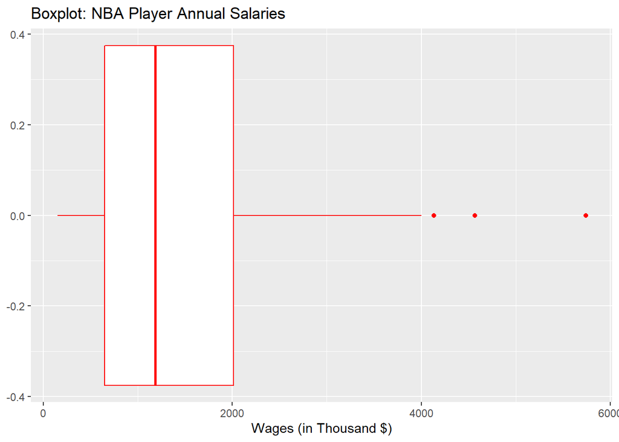

```
##    Min. 1st Qu.  Median    Mean 3rd Qu.    Max.
##     150     650    1186    1424    2014    5740
```

The annual salary contracts of NBA players are positively skewed with more than 50% earning over **1186** and average salary for each player is **1423.83**. If Mean > Median > Mode => POSITIVE SKEW

#**Problem 2**  
*Let’s investigate the relationships between variables in our dataset. In practice if two variables are highly correlated with one another, then we may run into the problems caused by multicollinearity. This will make it hard for ordinary least squares to decipher the effect of one variable from another in a regression model. One way of investigating the relationships is via their correlation. If you select the option of ’Correlation matrix’ from the ’View’ menu, and include all the variables in the dataset, this will output the bivariate correlations between all variables in the NBA dataset. This can be a useful tool to allow one to get a quick handle on the data by seeing how strong the relationship is between different variables in your dataset. Are there any variables that are particularly highly correlated with experience? What would be the issue of including both of these measures in aregression with wages as the dependent variable?*

#*Solution*

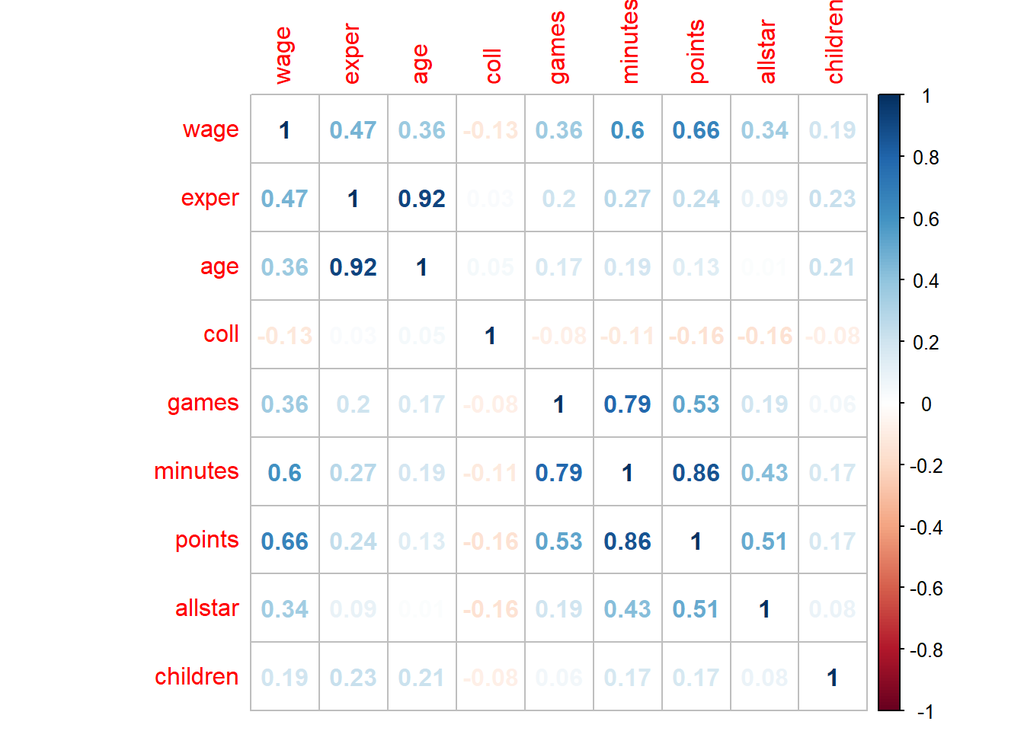

```r
library(corrplot)
cp=cor(nbasal %>% select(wage,exper,age,coll,games,minutes,points,allstar,children),method='spearman')
corrplot(cp,method='number')
```

We find that the following pairs: 1) age & experience 2) minutes & games 3) minutes and points  
are highly correlated (>65%)

#**Problem 3**  
*Another useful aspect of a correlation matrix is that it can give you a feel for which variables are correlated with your dependent variable. Which variables (other than the log of wages), show the highest correlation with wages?*  
#*Solution*

```
##          marr wage exper  age coll games minutes guard forward center points
## marr      1.0  0.2   0.3  0.4  0.0   0.1     0.1   0.0     0.0    0.0    0.1
## wage      0.2  1.0   0.4  0.3 -0.1   0.3     0.6  -0.1     0.1    0.1    0.7
## exper     0.3  0.4   1.0  0.9  0.1   0.1     0.2  -0.1     0.0    0.1    0.2
## age       0.4  0.3   0.9  1.0  0.1   0.1     0.1  -0.1     0.0    0.1    0.1
## coll      0.0 -0.1   0.1  0.1  1.0   0.0    -0.1   0.1     0.0    0.0   -0.1
## games     0.1  0.3   0.1  0.1  0.0   1.0     0.8   0.1     0.0   -0.2    0.5
## minutes   0.1  0.6   0.2  0.1 -0.1   0.8     1.0   0.1     0.0   -0.2    0.8
## guard     0.0 -0.1  -0.1 -0.1  0.1   0.1     0.1   1.0    -0.7   -0.4    0.1
## forward   0.0  0.1   0.0  0.0  0.0   0.0     0.0  -0.7     1.0   -0.4    0.0
## center    0.0  0.1   0.1  0.1  0.0  -0.2    -0.2  -0.4    -0.4    1.0   -0.1
## points    0.1  0.7   0.2  0.1 -0.1   0.5     0.8   0.1     0.0   -0.1    1.0
## rebounds  0.0  0.5   0.2  0.1 -0.1   0.3     0.6  -0.5     0.4    0.1    0.6
## assists   0.2  0.3   0.2  0.1  0.0   0.3     0.6   0.5    -0.3   -0.3    0.5
## draft      NA   NA    NA   NA   NA    NA      NA    NA      NA     NA     NA
## allstar   0.1  0.4   0.1  0.0 -0.1   0.2     0.4   0.0     0.0    0.0    0.6
## avgmin    0.1  0.6   0.2  0.1 -0.1   0.6     0.9   0.1     0.0   -0.2    0.9
## lwage     0.1  0.9   0.4  0.3 -0.1   0.4     0.6  -0.1     0.1    0.0    0.6
## black    -0.1  0.1   0.0 -0.1  0.0   0.1     0.1   0.1     0.1   -0.2    0.1
## children  0.3  0.2   0.2  0.2 -0.1   0.1     0.2   0.0     0.0    0.0    0.2
## expersq   0.3  0.3   1.0  0.9  0.0   0.1     0.1  -0.1     0.0    0.1    0.1
## agesq     0.4  0.3   0.9  1.0  0.1   0.1     0.1  -0.1     0.0    0.1    0.1
## marrblck  0.8  0.2   0.2  0.2  0.0   0.1     0.1   0.1     0.0   -0.1    0.1
##          rebounds assists draft allstar avgmin lwage black children expersq
## marr          0.0     0.2    NA     0.1    0.1   0.1  -0.1      0.3     0.3
## wage          0.5     0.3    NA     0.4    0.6   0.9   0.1      0.2     0.3
## exper         0.2     0.2    NA     0.1    0.2   0.4   0.0      0.2     1.0
## age           0.1     0.1    NA     0.0    0.1   0.3  -0.1      0.2     0.9
## coll         -0.1     0.0    NA    -0.1   -0.1  -0.1   0.0     -0.1     0.0
## games         0.3     0.3    NA     0.2    0.6   0.4   0.1      0.1     0.1
## minutes       0.6     0.6    NA     0.4    0.9   0.6   0.1      0.2     0.1
## guard        -0.5     0.5    NA     0.0    0.1  -0.1   0.1      0.0    -0.1
## forward       0.4    -0.3    NA     0.0    0.0   0.1   0.1      0.0     0.0
## center        0.1    -0.3    NA     0.0   -0.2   0.0  -0.2      0.0     0.1
## points        0.6     0.5    NA     0.6    0.9   0.6   0.1      0.2     0.1
## rebounds      1.0     0.1    NA     0.3    0.6   0.5   0.1      0.1     0.1
## assists       0.1     1.0    NA     0.4    0.6   0.4   0.0      0.2     0.1
## draft          NA      NA     1      NA     NA    NA    NA       NA      NA
## allstar       0.3     0.4    NA     1.0    0.5   0.3   0.1      0.1     0.1
## avgmin        0.6     0.6    NA     0.5    1.0   0.6   0.1      0.2     0.1
```

[output cut: 14 more lines]

```
## guard     -0.1      0.1
## forward    0.0      0.0
## center     0.1     -0.1
## points     0.1      0.1
## rebounds   0.1      0.0
## assists    0.1      0.1
## draft       NA       NA
## allstar    0.0      0.0
## avgmin     0.1      0.1
## lwage      0.3      0.1
## black      0.0      0.4
## children   0.2      0.2
## expersq    0.9      0.2
## agesq      1.0      0.2
## marrblck   0.2      1.0
```

We see that wage is highly correlated (>0.3) with *experience,age,games, minutes, points, rebound, assists,allstar, avgmin, experience square and age square

##**Problem 4**  
*Graphically investigate whether players who are more experienced earn more. How strong is the correlation between these two variables?*

#*Solution*

```
## [1] 0.4091764
```

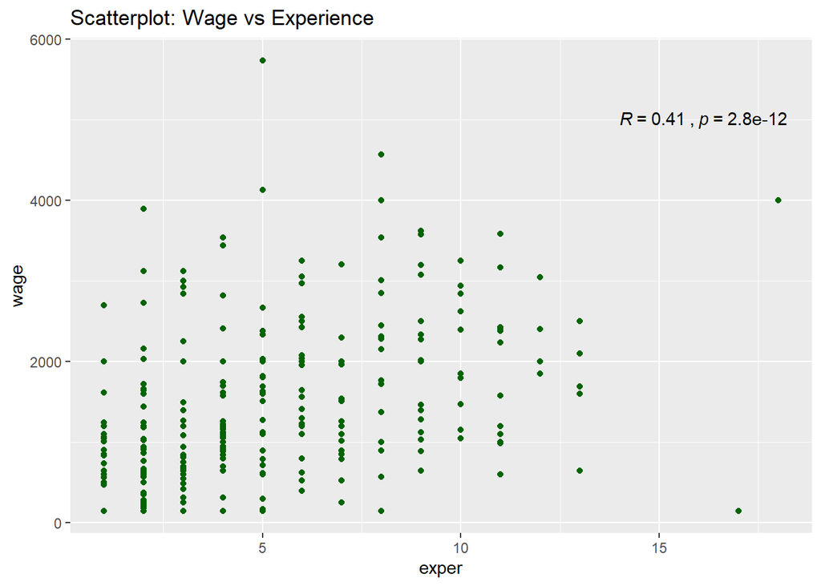

##**Problem 5**  
*Create an ordinary least squares model which investigates how experience affects a player’s wages.*

#*Solution*

```
##
## Call:
## lm(formula = wage ~ exper, data = nbasal)
##
## Residuals:
##     Min      1Q  Median      3Q     Max
## -2703.3  -673.6  -193.2   474.2  4330.5
##
## Coefficients:
##             Estimate Std. Error t value Pr(>|t|)
## (Intercept)   807.93     100.85   8.011 3.53e-14 ***
## exper         120.32      16.42   7.327 2.79e-12 ***
## ---
## Signif. codes:  0 '***' 0.001 '**' 0.01 '*' 0.05 '.' 0.1 ' ' 1
##
## Residual standard error: 914 on 267 degrees of freedom
## Multiple R-squared:  0.1674, Adjusted R-squared:  0.1643
## F-statistic: 53.69 on 1 and 267 DF,  p-value: 2.787e-12
```

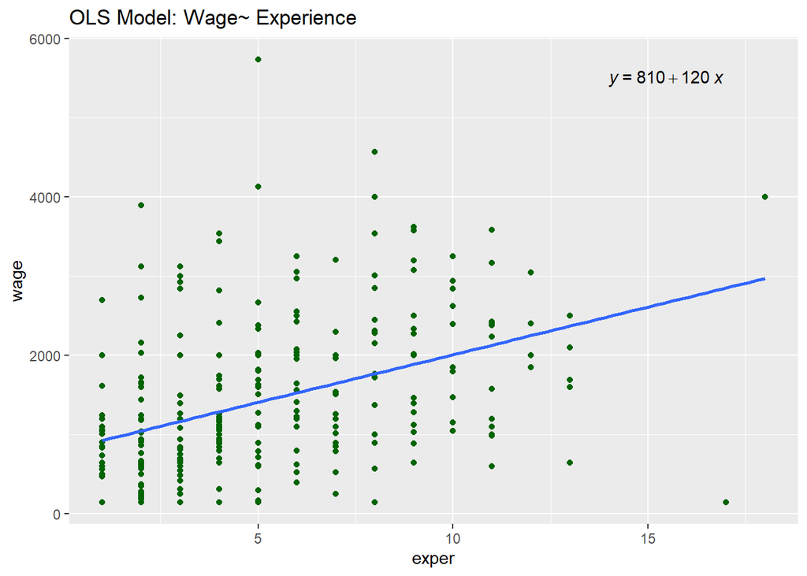

##**Problem 6**  
*What is the average wage increase associated with an increase in experience by one year implied by your model?*

#*Solution*  
For every 1 additional year of experience one can expect the wage to increase by **120.32** thousand dollars.

##**Problem 7**  
*Do you think that the estimates of the effect of experience on wages is likely too big or too small? Which Gauss-Markov assumption is being violated, and why?*

#*Solution*  
In my view this coefficient likely overstates the effect of experience on wages, since those who are better tend to be employed as professional basketball players forlonger, and hence are paid more. In other words there is another third variable’quality’ which is causing both wages and experience to be higher. A measure of player’s quality is contained within the variables: ‘points’, ‘minutes’, ‘rebounds’, etc. variables. So their inclusion is likely to bring the estimate of the effect of experience down.

##**Problem 8**  
*Create another regression with wages as a dependent variable, and age as the independent variable (along with a constant). Does this imply that the effect of age is positive or negative?*

#*Solution*

```
##
## Call:
## lm(formula = wage ~ age, data = nbasal)
##
## Residuals:
##     Min      1Q  Median      3Q     Max
## -2445.5  -683.1  -231.2   545.0  4154.0
##
## Coefficients:
##             Estimate Std. Error t value Pr(>|t|)
## (Intercept) -1341.73     467.89  -2.868  0.00447 **
## age           100.95      16.95   5.956 8.14e-09 ***
## ---
## Signif. codes:  0 '***' 0.001 '**' 0.01 '*' 0.05 '.' 0.1 ' ' 1
##
## Residual standard error: 941.1 on 267 degrees of freedom
## Multiple R-squared:  0.1173, Adjusted R-squared:  0.114
## F-statistic: 35.47 on 1 and 267 DF,  p-value: 8.137e-09
```

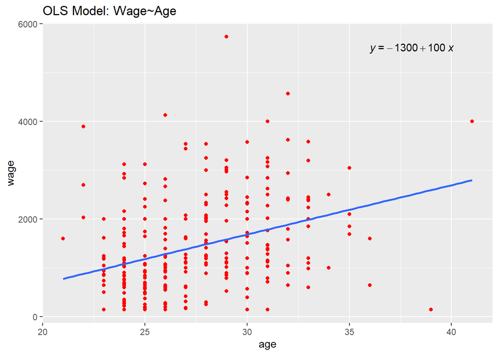

##**Problem 9**  
*What would would be the average wage implied by your model for an individual of 30? What about for a 90 year old? What is the problem with the latter estimate?*

#*Solution*  
The expected annual salary of a 30 year old NBA player is predicted to be **$1686.91 Thousand**. The observed average salary for a 30 year old NBA player is **$1545.78 Thousand**. For a 90 year old it is expected to be **$7744.19 Thousand**.

While the predicted value for 30 year old seems sound and reasonable but for 90 year old the salary expectations are absurd esp a athelete who slowsdown with age. This latter prediction is completely **out of sample**,and also very unrealistic. One has to be very careful when extending the results of a regression to make out of sample predictions. *(Out of sample here means thatwe currently do not have any data for the wages of 90 year old basketball players.)*

##**Problem 10**  
*How might we rectify the issue of the unrealistic estimates from the previousmodel?*  
#*Solution*  
One way might be to include the square of the age in the regression, as this wouldsuggest that there might be diminishing marginal returns to age.  
The OLS regression outcome for such a model would be:

```
##
## Call:
## lm(formula = wage ~ age + agesq, data = nbasal)
##
## Residuals:
##     Min      1Q  Median      3Q     Max
## -2288.7  -693.0  -226.4   533.8  4132.2
##
## Coefficients:
##              Estimate Std. Error t value Pr(>|t|)
## (Intercept) -2701.009   3045.888  -0.887    0.376
## age           197.275    213.941   0.922    0.357
## agesq          -1.679      3.718  -0.452    0.652
##
## Residual standard error: 942.5 on 266 degrees of freedom
## Multiple R-squared:  0.1179, Adjusted R-squared:  0.1113
## F-statistic: 17.78 on 2 and 266 DF,  p-value: 5.636e-08
```

##**Problem 11**  
*Now create a regression withbothexperience and age in the model. What hashappened to the sign of the coefficient on age? Why has this happened?*

#*Solution*

```
##
## Call:
## lm(formula = wage ~ age + exper, data = nbasal)
##
## Residuals:
##     Min      1Q  Median      3Q     Max
## -2653.5  -616.1  -152.6   400.1  4519.6
##
## Coefficients:
##             Estimate Std. Error t value Pr(>|t|)
## (Intercept)  3295.29    1096.40   3.006   0.0029 **
## age          -110.12      48.34  -2.278   0.0235 *
## exper         223.69      48.21   4.640 5.48e-06 ***
## ---
## Signif. codes:  0 '***' 0.001 '**' 0.01 '*' 0.05 '.' 0.1 ' ' 1
##
## Residual standard error: 906.9 on 266 degrees of freedom
## Multiple R-squared:  0.1834, Adjusted R-squared:  0.1772
## F-statistic: 29.86 on 2 and 266 DF,  p-value: 1.996e-12
```

The sign on age has now turned *NEGATIVE*. It was previously positive. The coefficient on experience has nearly *doubled*. This unstable change in the coefficient values is due to high **multicollinearity** between **age** and **experience**.

##**Problem 12**  
*Let’s now try to examine whether individuals who score more points tend to earnmore by creating a regression of wages on points per game (and a constant).*

#*Solution*

```
##
## Call:
## lm(formula = wage ~ points, data = nbasal)
##
## Residuals:
##      Min       1Q   Median       3Q      Max
## -1925.03  -483.60   -91.01   389.97  2757.68
##
## Coefficients:
##             Estimate Std. Error t value Pr(>|t|)
## (Intercept)  287.101     92.137   3.116  0.00203 **
## points       111.330      7.817  14.243  < 2e-16 ***
## ---
## Signif. codes:  0 '***' 0.001 '**' 0.01 '*' 0.05 '.' 0.1 ' ' 1
##
## Residual standard error: 755.1 on 267 degrees of freedom
## Multiple R-squared:  0.4317, Adjusted R-squared:  0.4296
## F-statistic: 202.9 on 1 and 267 DF,  p-value: < 2.2e-16
```

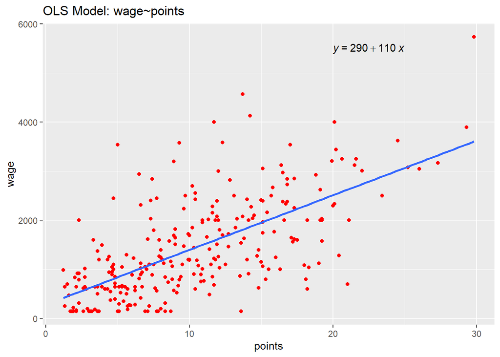

An increase of 10 points will result in a wage increase of **$1113.3018613 Thousands**.

##**Problem 13**  
*You can look at a graph of the residuals (the estimated errors) from the regression, by clicking into the model (if you are not already in the model window), andnavigating to Graphs→Residual plot. There are then a number of differentoptions available, from seeing a plot of residuals against observation number toseeing a plot against the values of experience. Which of these plots should you useto graphically inspect for heteroscedasticity?*

#*Solution*

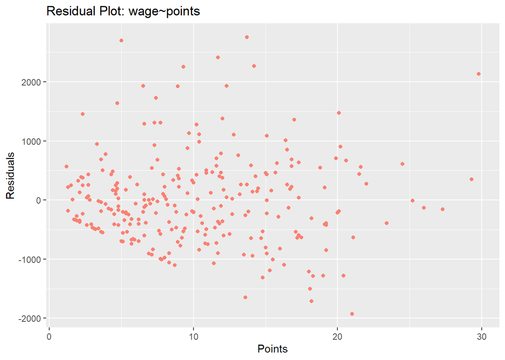

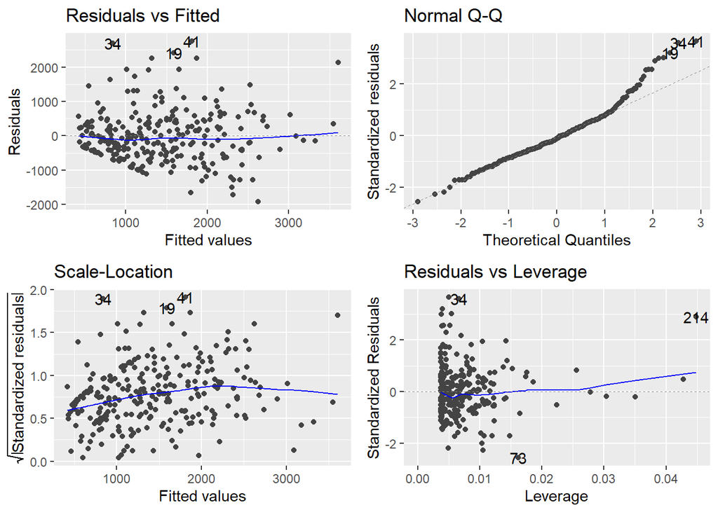

##**Problem 14**  
*Does there appear to be heteroscedasticity? What might be causing it? How mightwe rectify it?*  
#*Solution*  
We do see an issue of **Heteroskedstacity**. The variance for errors does not seem to be constants and is increasing as points increases. There is definitely evidence of systematic increases in the variance of our estimates as points increases from 0-15. There is then a decline in variance towards the latter end of the points spectrum. This makes intuitive sense. When players score few points, they are not paid much. When they score a reasonable number of points they tend to be paid more, but there is a higher variance. This could be because of the fact that players on a basketball team occupy different positions - some are more focussed on scoring, others on defending. This would mean that once a threshold number of points is reached the players are paid more or less dependent on their respective abilities in their positions. When a player scores a high number of points, they are in short supply, and can hence command a higher wage.

##**Problem 15**  
*Do you think that the effect of points on wages predicted by your model is too highor low? Why might this be the case?*  
#*Solution*  
I suspect it is too high. There is probably some reverse causality happening,whereby players that are paid more tend to score more points. Also, points likelyalso captures some of the effects of other variables that are important in determiningwages. For example, players from better teams have better team mates, and hencetend to have more chances to score. At the same time the players on the betterteams tend to be paid more.

##**Problem 16 & 17**  
*Create two new variables in R: ’pointsq’ and ’pointsc’equal to the square of points and its cube respectively. Now create two new regression models (keeping your current regression of wageson points):*

$wage_i=α+β_1points_i+β_2points^2_i$

$wage_i=α+β_1points_i+β_2points^2_i+β_3points^3_i$

1. Which of these regressions has the highest value of R-squared? What doesthis mean?
2. What is the interpretation of the coefficient on ’pointsc’ in the last regression model?
3. Which of these regressions has the highest value of adjusted R-squared?
4. Out of the three specifications, which would you prefer?

#*Solution*

```
##
## Call:
## lm(formula = wage ~ points + pointsq, data = data)
##
## Residuals:
##      Min       1Q   Median       3Q      Max
## -1959.51  -501.26   -83.48   387.77  2789.20
##
## Coefficients:
##             Estimate Std. Error t value Pr(>|t|)
## (Intercept) 382.5498   147.1016   2.601 0.009827 **
## points       90.1186    26.6477   3.382 0.000828 ***
## pointsq       0.8718     1.0470   0.833 0.405776
## ---
## Signif. codes:  0 '***' 0.001 '**' 0.01 '*' 0.05 '.' 0.1 ' ' 1
##
## Residual standard error: 755.5 on 266 degrees of freedom
## Multiple R-squared:  0.4332, Adjusted R-squared:  0.429
## F-statistic: 101.7 on 2 and 266 DF,  p-value: < 2.2e-16
```

```
##
## Call:
## lm(formula = wage ~ points + pointsq + pointsc, data = data)
##
## Residuals:
##     Min      1Q  Median      3Q     Max
## -1844.2  -479.9  -126.7   395.9  2808.0
##
## Coefficients:
##             Estimate Std. Error t value Pr(>|t|)
## (Intercept)  47.2034   221.6900   0.213  0.83155
## points      211.1742    65.7160   3.213  0.00147 **
## pointsq      -9.8135     5.4093  -1.814  0.07078 .
## pointsc       0.2581     0.1282   2.013  0.04513 *
## ---
## Signif. codes:  0 '***' 0.001 '**' 0.01 '*' 0.05 '.' 0.1 ' ' 1
##
## Residual standard error: 751.2 on 265 degrees of freedom
## Multiple R-squared:  0.4418, Adjusted R-squared:  0.4354
## F-statistic:  69.9 on 3 and 265 DF,  p-value: < 2.2e-16
```

1. The latter model has a higher R-squared of 0.44. This means that these inde-pendent variables explain 44% of the variation in the dependent variable.
2. This would suggest that there is diminishing diminishing (yep two diminish-ings!) marginal returns to points. In other words it is pretty nonsensical.
3. The last regression still has the highest adjusted R-squared.
4. The first regression (with only wages regressed on points), since it is parsi-monious, and has a clear interpretation. The latter of the three especially is overfitting the data. I include the last regression fitted residuals below so you can see for yourself. Don’t let apophenia (seeing meaningless patterns in data) get the better of you - a linear line is still better than this curve

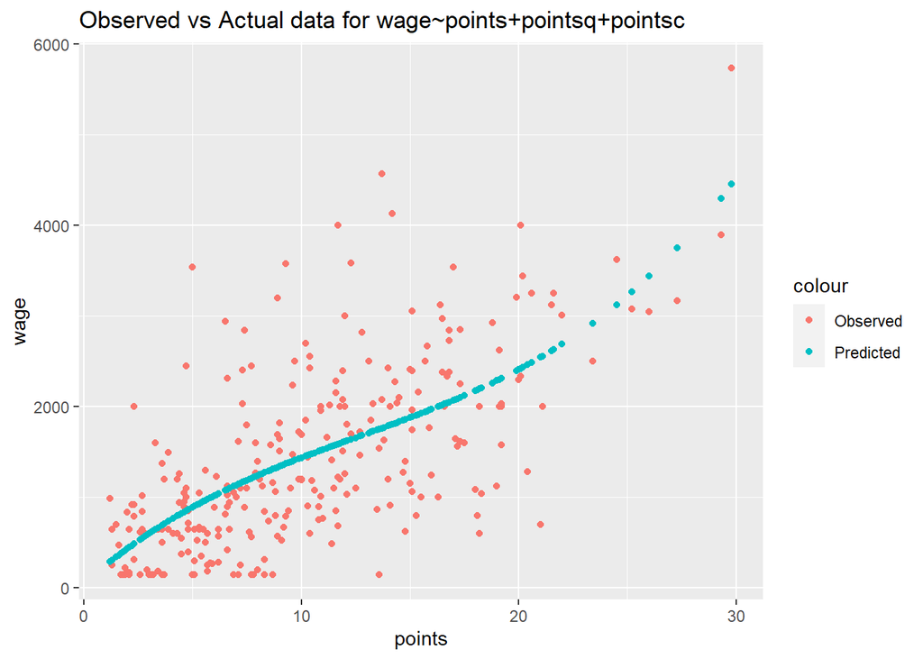

##**Problem 18**  
*Freestyle: try to create a model which you believe captures explains players wages best in terms of other attributes*

#*Solution*

$wage_i=α+β_1points_i+β_2exper^2_i+\beta_3games$

```
##
## Call:
## lm(formula = wage ~ points + expersq + games, data = nbasal)
##
## Residuals:
##      Min       1Q   Median       3Q      Max
## -1858.60  -406.89   -64.29   334.06  2825.40
##
## Coefficients:
##             Estimate Std. Error t value Pr(>|t|)
## (Intercept) 234.2376   158.0776   1.482    0.140
## points      109.3355     8.4666  12.914  < 2e-16 ***
## expersq       5.8454     0.9358   6.247 1.66e-09 ***
## games        -2.2406     2.6424  -0.848    0.397
## ---
## Signif. codes:  0 '***' 0.001 '**' 0.01 '*' 0.05 '.' 0.1 ' ' 1
##
## Residual standard error: 707.2 on 265 degrees of freedom
## Multiple R-squared:  0.5053, Adjusted R-squared:  0.4997
## F-statistic: 90.22 on 3 and 265 DF,  p-value: < 2.2e-16
```